# Understanding the *factors* associated with **Loans at Prosper Marketplace**

# 1 Prosper Dataset: *Top Down*

In this exersize, we deal with a dataset from [Prosper](https://en.wikipedia.org/wiki/Prosper_Marketplace)

ProsperLoans dataset contains peer to peer low-medium sized loan transactions. Current dataset has over .11 million transactions, consisting schemas related to buyers, seller & the loan. To understand the sructure of the data and criticality of each variable we do an Exploratory data analysis (EDA) on the structure of the data."

> EDA of the above, shall benefit us in a number of ways:
1. Tracking collinearty & multi-collinearity
2. Tracking hidden relationships
3. Checking for outliers & imputation of missing values

We will also share the graphical represntation of some of the factors discussed. This is because, Data visualization is a pivotal part of data analysis. The below link explains the need: [Anscombe Quartlet](https://en.wikipedia.org/wiki/Anscombe%27s_quartet)

# 2 Analyzing *schemas* of the dataset

Number of factors in the dataset

```
## [1] 81
```

Some important variables around which our EDA revolves:

1. Credit scores
2. Delinquency Accounts
3. Credit Accounts
4. Borrower’s income
5. Investors
6. Estimated Lossed
7. Estimated Fees
8. Lender Yields

## 2.1 Does More friends mean More Investments from them?

```
We take 2 variables here:-

1.  InvestmentFromFriendsAmount
2.  InvestmentFromFriendsCount

with the intuition that more friends will bring more investments.
```

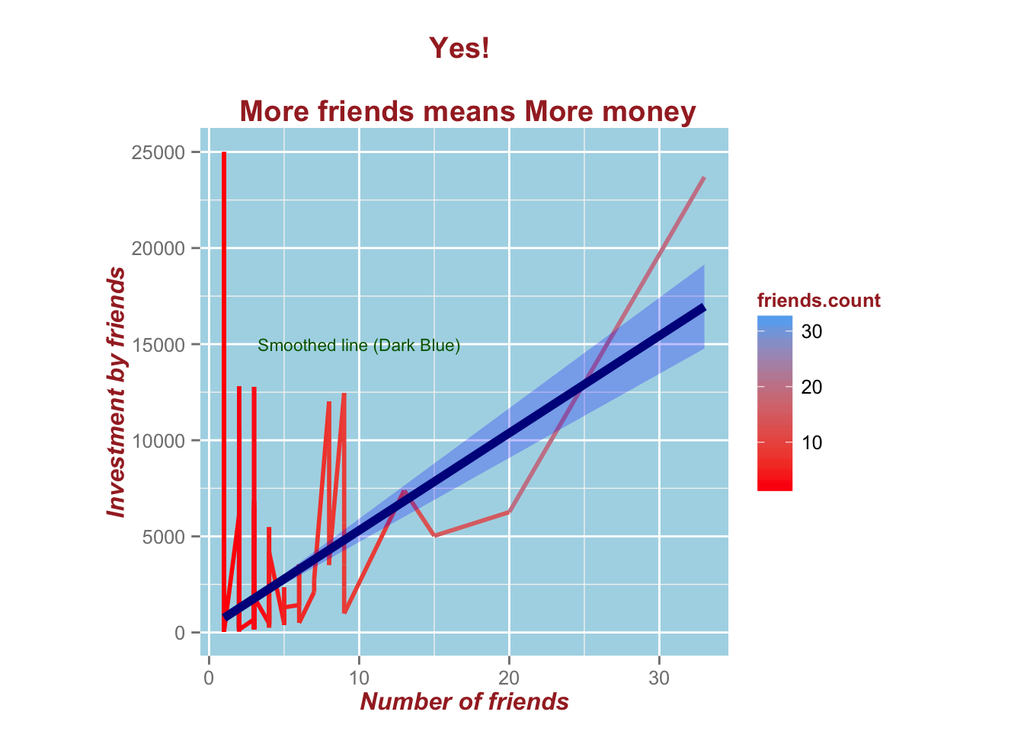

## 2.2 Does Debt/Income correlates positively with Borrower rate?

```
We take 2 variables here:-

1.  BorrowerRate
2.  DebtToIncomeRatio

with the notion that borrowers with higher levels of existent debt relative
to their income, shall get new loans at higher costs.
```

Correlation between Debt/Income and Borrower rate is

0.06286032

Nothing significant from this data could be concluded about the dependence of (Debt/Income) ratio on Borrower Rate

## 2.3 Estimated Yield must vary proportionately with Estimated-Loss

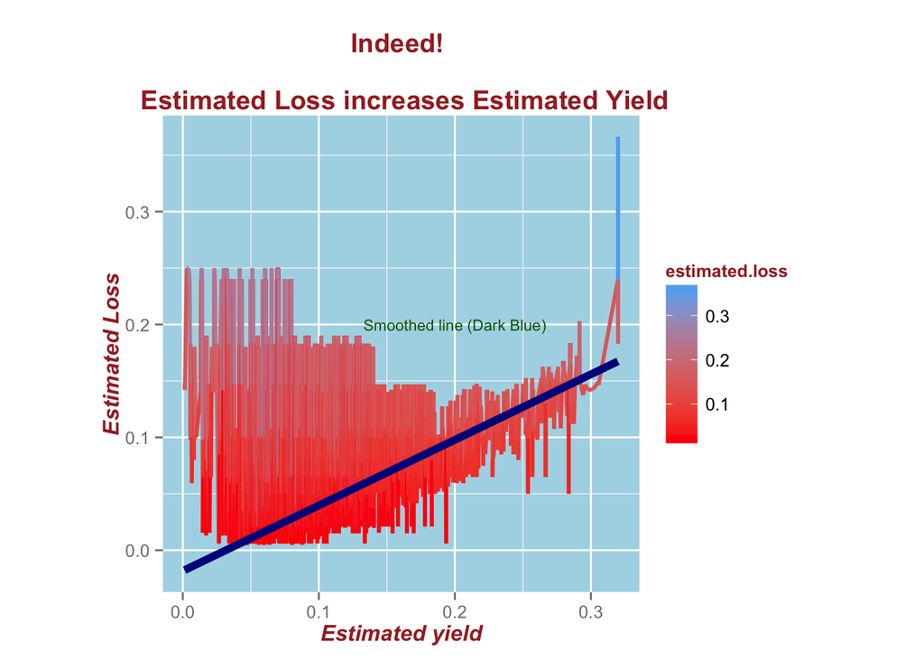

```
We take the variable

1.  ProsperScore

2.  LenderYield

To track how lender's yield gets altered by Prosper's score
```

## 2.5 Amount Delinquent is less for people with high Income?

```
Deliquency is state of defaulting on a loan payment by greater than 30 days. This reduces the financial credibility of a borrower

Hence the intuition is that High income individuals
should not be facing a hgh deliquency amount
```

Surpringly, There is no strong correlation between monthly income & Delinquent Amount 0.001861629

## 2.6 Do borrower’s with high ratings have lower number of Current Delinquencies

```
High credit ratings go hand in hand with borrowers who have been consistent with their bill payments.

Intuition: Individuals with high ratings should not be having a higher number deliquent accounts.
```

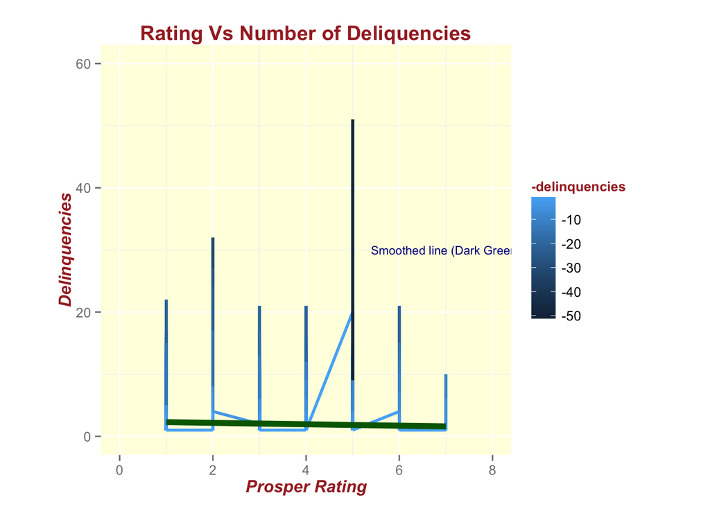

A significant relationship between Prosper Ratings and number of Deliquent accounts can’t be established from the given data!

## 2.7 Are multiple recommendations always given to people with higher income?

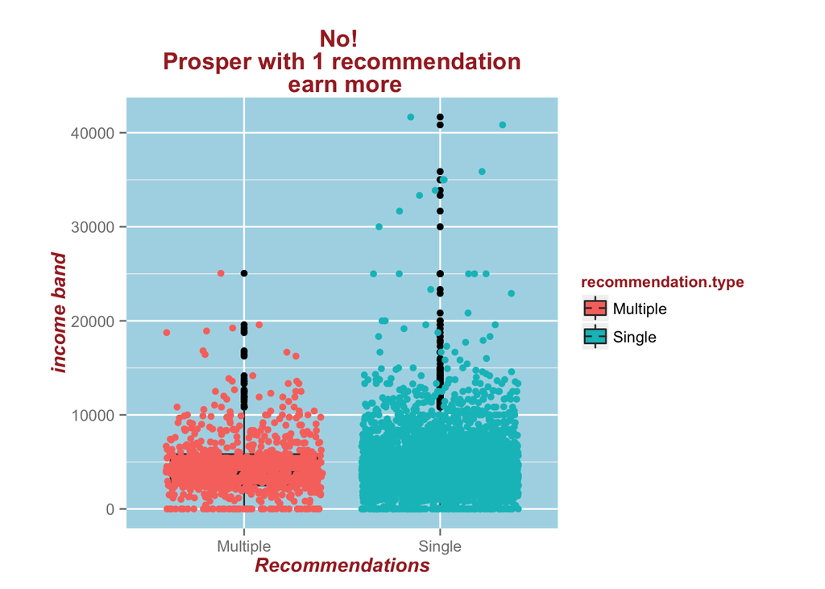

## 2.8 Do borrower’s with higher Credit scores have lower APR?

```
we take the below variables, and study their correlation across all values

1.  CreditScoreRangeUpper

2.  BorrowerAPR
```